# Assess genotyping error rate via `whoa`

Eric C. Anderson

Last Updated: 2020-05-14

One of the referees was curious about how accurate (or inaccurate) the process of imputation and phasing might have been on our relatively low coverage whole genome sequencing data. He was also curious about what effect it might have on the trees that we inferred from the phased haplotype data. In this notebook we begin to address that issue by first estimating the heterozygote miscall rate of our data amongst fall-run Chinook salmon from the Sacramento-San Joaquin Basin. Heterozygote miscall, as a common type of genotyping error in genotyping-by-sequencing data, was discussed in Hendricks et al. (2018), where there was also mention of software for estimating heterozygote miscall rates, as a function of read depth, via distortions from Hardy-Weinberg equilibrium. A method for doing so is now distributed as the R package ‘whoa’ by Eric C. Anderson, available from CRAN.

Here, our goal is to assess whether the imputed genotypes found amongst a large group of fish from several largely undifferentiated populations (the fall and late-fall collections from the Central Valley of California) are in proportions that indicate that there has not been a gross under-identification of heterozygous individuals.

Sacramento-San Joaquin Fall run Chinook salmon are largely undifferentiated between different tributaries (and from the Late-Fall run) which makes them suitable for consideration for use in ‘whoa.’

This notebook will draw upon the intermediate files produced in 004.

```r
library(tidyverse)
library(vcfR)

# You must use a post-CRAN-release version of 'whoa'
# that deals with read depths of 0 (from fully imputed sites) appropriately.
# devtools::install_github("eriqande/whoa")
library(whoa)

dir.create("intermediates/204", showWarnings = FALSE, recursive = TRUE)
dir.create("outputs/204", showWarnings = FALSE, recursive = TRUE)
```

# First explore the raw gentoypes called by GATK

Since GATK seems to not include population frequency information to calculate genotype posteriors (and, rather, appears to call genotypes based on the maximum of the genotype likelihoods), we expect that our low-read depth sequencing will yield raw genotypes from GATK that show evidence of extreme deficits of heterozygotes.

```bash
# get names of the fall and late fall central valley fish:
bcftools query -l intermediates/004/almost-ready-for-imputation.vcf | \
  awk '/San_Joaquin_River_Fall/ || /Coleman_Hatchery_Late_Fall/ || Feather_River_Hatchery_Fall' \
  > intermediates/204/cv-fall-run-names.txt

# pick out just the fall/late-fall from the CV
bcftools view -S intermediates/204/cv-fall-run-names.txt -Oz \
  intermediates/004/almost-ready-for-imputation.vcf > intermediates/204/fall-late-fall-raw-from-gatk-5.16Mb.vcf.gz
```

```r
raw_gatk <- read.vcfR("intermediates/204/fall-late-fall-raw-from-gatk-5.16Mb.vcf.gz")
```

[output not shown]

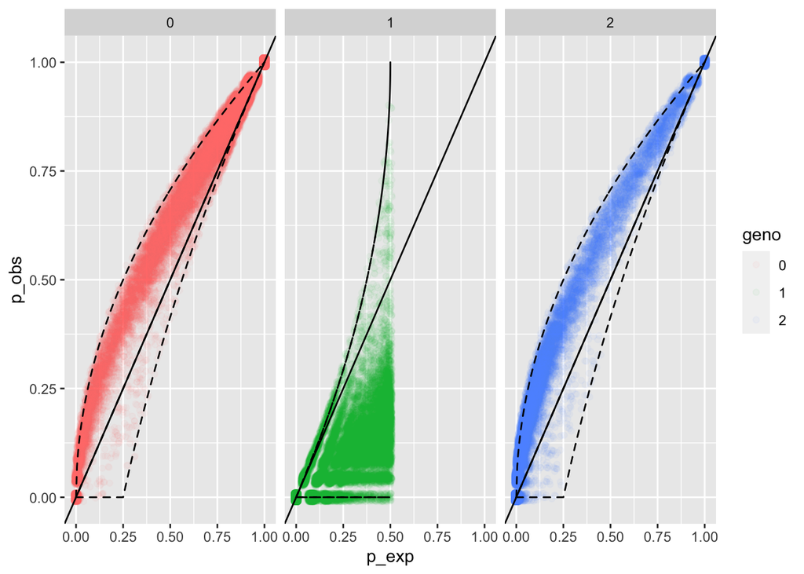

```r
raw_freqs <- exp_and_obs_geno_freqs(raw_gatk)

geno_freqs_scatter(raw_freqs, alpha = 0.04, max_plot_loci = 1e15)
```

Indeed. As expected, the raw genotype calls from GATK show substantial departures from HWE in a collection of from fish which it is to be expected.

# Get the VCF of imputed/phased haplotypes from 004 and add depths to it

Here we test for an improvement in genotype proportions after imputation of genotypes from genotype likelihoods, and using haplotype information and linkage disequilibrium

```bash
cp intermediates/004/almost-ready-for-imputation.vcf intermediates/204
bgzip -f intermediates/204/almost-ready-for-imputation.vcf
bcftools index intermediates/204/almost-ready-for-imputation.vcf.gz


# reattach the DP information
bcftools annotate -a  intermediates/204/almost-ready-for-imputation.vcf.gz -c FMT/DP \
  -Oz -o intermediates/204/imputed-all-fish-with-DP.vcf.gz intermediates/004/greb1l-imp-phased.vcf.gz

# pick out just the fall/late-fall from the CV
bcftools view -S intermediates/204/cv-fall-run-names.txt -Oz \
  intermediates/204/imputed-all-fish-with-DP.vcf.gz > intermediates/204/fall-late-fall-imp-and-phased-5.16Mb.vcf.gz
```

# Now, run it through `whoa`

First read it in and make a geno_freq scatter of it:

```r
v <- read.vcfR("intermediates/204/fall-late-fall-imp-and-phased-5.16Mb.vcf.gz")
```

[output not shown]

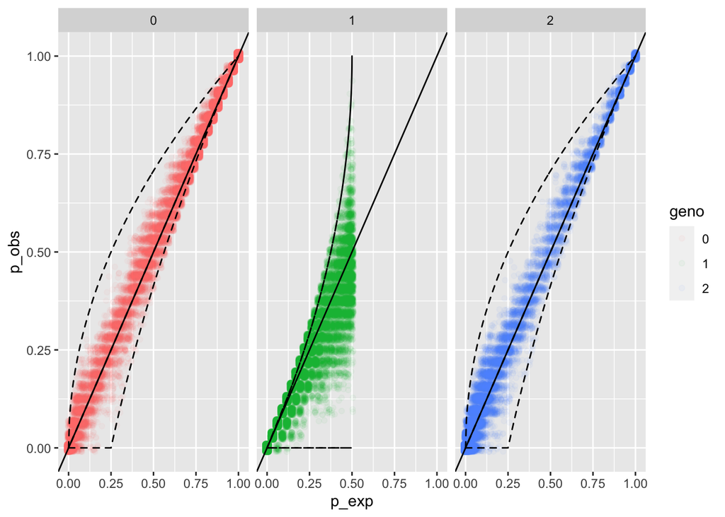

```r
gfreqs <- exp_and_obs_geno_freqs(v)

geno_freqs_scatter(gfreqs, alpha = 0.04, max_plot_loci = 1e15)
```

That is a considerable improvement. We can conclude from this that, at a gross level, the imputation from BEAGLE is working reasonably well, despite the fact that fish from multiple populations were included together in the BEAGLE imputation analysis.

Now, try to infer an overall het miscall rate:

```r
overall <- infer_m(v, minBin = 1e15)
```

Look at the posterior mean estimate:

```r
overall$m_posteriors
```

| bin | mean | lo95 | hi95 | total_n | mean_dp |
| --- | --- | --- | --- | --- | --- |
| 1 | 0.0550131 | 0.05274306 | 0.05718051 | 817248 | 1.558046 |

So, a het miscall rate of a little greater than 5%. That is quite low. Note that a more suitable name for this quantity might be the “heterozygote distortion rate,” since it indicates that there is a distortion of the heterozygote genotype frequencies that is consistent with heterozygotes being incorrectly called as homozygotes at a rate of 5%; however, the actual rate at which heterozygotes are called as homozygotes may be higher than this (as will be seen in the next analysis, 204-02).

Let’s look at the MCMC trace:

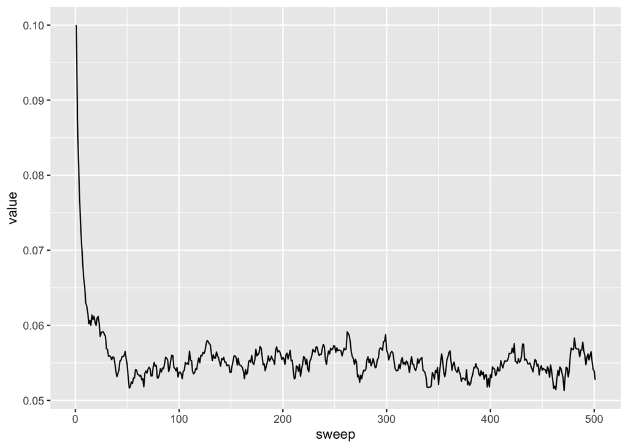

```r
ggplot(overall$m_traces, aes(x = sweep, y = value)) +
  geom_line()
```

That shows good mixing.

Now, let’s see if we can break things down by different read depth bins:

```r
binned <- infer_m(v, minBin = 2e04)
```

Check out the posterior means:

```r
binned$m_posteriors
```

| bin | mean | lo95 | hi95 | total_n | mean_dp |
| --- | --- | --- | --- | --- | --- |
| 1 | 0.0678084884 | 6.281506e-02 | 0.0738049403 | 217304 | 0.000000 |
| 2 | 0.0881385697 | 8.347694e-02 | 0.0932124219 | 247344 | 1.000000 |
| 3 | 0.0773298154 | 7.296374e-02 | 0.0815839359 | 176824 | 2.000000 |
| 4 | 0.0263752392 | 2.065429e-02 | 0.0320474388 | 97086 | 3.000000 |
| 5 | 0.0017019866 | 5.866479e-05 | 0.0044685566 | 45267 | 4.000000 |
| 6 | 0.0001670703 | 6.737005e-07 | 0.0006164212 | 33423 | 5.983664 |

Let’s plot the traces:

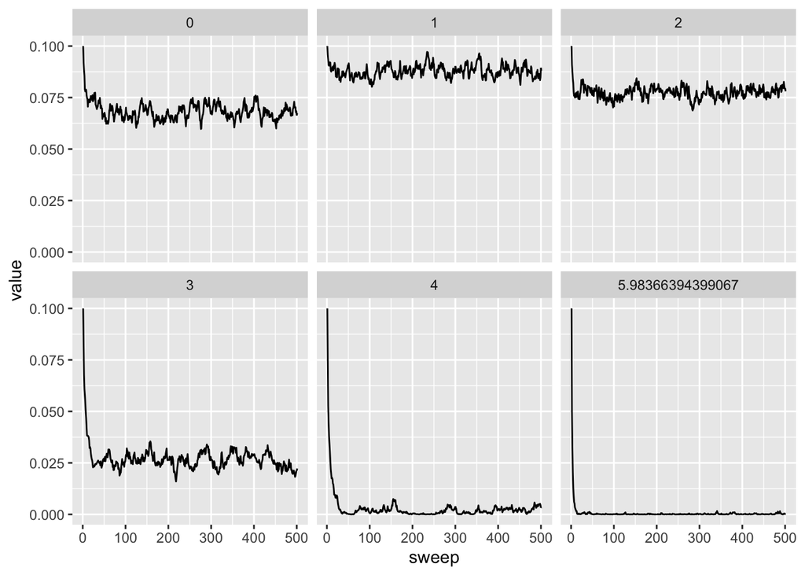

```r
binned$m_traces %>%
  left_join(binned$m_posteriors %>% select(bin, mean_dp)) %>%
  ggplot(., aes(x = sweep, y = value)) +
  geom_line() +
  facet_wrap(~ as.factor(mean_dp))
```

So, that shows what we expect: that heterozygotes appear to be miscalled as homozygotes at a higher rate when the read depth is low. This is exactly what we expect.

Note that these are error estimates for sites across the whole 5.16 Mb. We might expect the imputation and the phasing to be more accurate in areas with high LD, such as what we find in the RoSA.

## Effective rate of genotyping errors

Also, those esimated heterozygote miscall rates are the rates at which heterozygotes are miscalled as homozygotes (the most common type of genotyping error with these sorts of data). However, only a fraction of the sites are heterozygous. So, what does that translate to for these fish in terms of average rate of genotyping error? Well it depends on the allele frequencies. Let’s do a quick calculation:

```r
vt <- vcfR2tidy(v)$gt %>%
  mutate(DP = ifelse(is.na(gt_DP), 0, gt_DP)) %>%
  select(-gt_DS, -gt_GP, -gt_DP, -gt_GT_alleles)

dpjoins <- binned$m_posteriors %>%
  mutate(DP = as.integer(mean_dp)) %>%
  select(DP, mean) %>%
  rename(est_hmr = mean)

vt_with_hmr <- vt %>%
  left_join(dpjoins, by = "DP") %>%
  mutate(est_hmr = ifelse(is.na(est_hmr), 0.00138, est_hmr)) # if DP > 5 just say het miscall rate is 0.00138

vt_with_hmr %>%
  separate(gt_GT, into = c("a", "b"), convert = TRUE, sep = "\\|") %>%
  gather(key = "gene_copy", value = "allele", a, b) %>%
  group_by(POS) %>%
  mutate(
    n1 = sum(allele == 1),
    n0 = sum(allele == 0)
  ) %>%
  mutate(het_freq = 2 * n1 / (n0 + n1) * n0 / (n0 + n1)) %>%
  mutate(exp_geno_rate = het_freq * est_hmr) %>%
  ungroup() %>%
  summarise(mean_est_geno_err_rate = mean(exp_geno_rate))
```

| mean_est_geno_err_rate |
| --- |
| 0.01340249 |

So, if we use the rate of heterozygote miscalls estimated here from distortions from HWE, and we only count heterozygote miscalls, we get a rate of about 1.3% of all genotypes being incorrect. That is not a high fraction of all genotypes that are expected to be incorrect.

However, a more definitive comparison would involve comparing the imputed genotypes of high-read depth individuals to the imputed genotypes from those same individuals after subsampling the reads from them to a lower read depth, like 1.5. This is done in the next notebook (204-02)

# Running Time

Running the code and rendering this notebook required approximately this much time on a Mac laptop of middling speed:

```r
Sys.time() - start_time
```

```
## Time difference of 1.16481 mins
```

Citations

Hendricks, Sarah, Eric C. Anderson, Tiago Antao, Louis Bernatchez, Brenna R. Forester, Brittany Garner, Brian K. Hand, et al. 2018. “Recent Advances in Conservation and Population Genomics Data Analysis.” *Evolutionary Applications* 11 (8): 1197–1211. doi:10.1111/eva.12659.